# Project-based engineering competition in upper-level engineering laboratory

## Ryan C. Cooper

[figure not shown]

# About me - Ryan C. Cooper

**GitHub**: [@cooperrc](https://github.com/cooperrc)

**email:** ryan.c.cooper@uconn.edu

**Twitter**: [@cooperrc84](https://twitter.com/cooperrc84)

- Assistant Professor-in-Residence
- University of Connecticut Mechanical Engineering Department
- Father of two boys
- Runner, bicyclist, and skateboarder

[video not shown]

# Accessing this presentation and *more*

[figure not shown]

- My website has Open Educational Resources: cooperrc.github.io
  - Join me, redistribute work, add suggestions
  - Textbooks should be **open** and **educational**
- These slides are hosted at github.com/cooperrc/2021-ASEE-NE_PjBL-labs
  - code to evaluate grades included
  - student data is not online (some info is PII)

# What is Project/Problem-Based Learning

## Problem-based Learning (PBL)

- Identify a problem
- Give clear instructions or steps to solve the problem

## Project-Based Learning (PjBL)

- Identify a clear goal
- Students iterate problem-solving approaches
- Design their own approach

# Motivation - Why am I using Projects and Problems?

- Students expect a hands-on engineering experience
- We, *professors*, give them an analytical background
- Computational work (i.e. Jupyter) s used here to connect empirical+analytical

[figure not shown]

# Motivation - Why am I using Projects and Problems?

## Most important ABET outcomes ranked by practicing engineers, employers, and recent graduates

### 1. problem solving

Students need practice solving problems

### 2. communication

Students need to share results e.g. improve technical writing

# Grading PBL + PjBL work: Specifications grading

- Lab reports are given scores
- Scores that meet overall specifications (>70) pass
- Detailed rubric focuses TA feedback
- Token system:
  - Groups have 2 tokens
  - Token is used for late assignment or revision
- Also called competency-based or *mastery-based* [I don't like this term]

# Methods: Fall 2018 + Fall 2019 - Fall 2020

[figure not shown]

- 5 PBL labs with content in Jupyter (Labs 0-4)
- 1 PjBL lab open-ended with definite goal Lab 5
  - $150 cash prize *most accurate*
  - party for *most precise section*
- Assess technical writing improvements with [rubric](https://github.com/cooperrc/sensors_and_data/blob/master/Rubric.pdf)
- survey students for most important skills
- survey students for capstone preparedness
- measure total error in student Project predictions
- *I assumed* improvements in technical writing scores are improvements in communication
- *I feared* students with >70 on lab 0 would decrease scores

# Methods: Fall 2018 + Fall 2019 - Fall 2020

[figure not shown]

# Results: Labs 0-4 saw continuous improvement

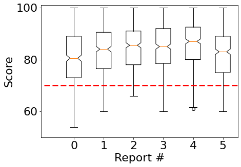

# Individual technical writing showed continuous improvement

- Average slope of grades from 0-4 calculated
- Plotted here vs grade on Lab 0
- Over 56% showed improvement
- 30-40% maintained high quality work
- less than 4% of class could not meet standards, but showed improvemnt

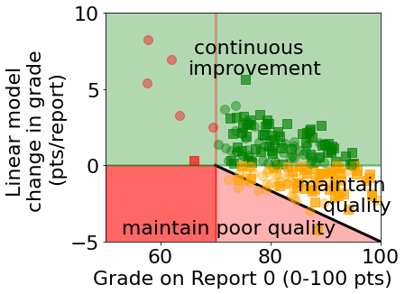

# Problem-solving evaluated with project results

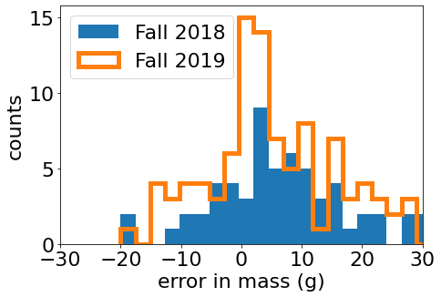

# Student preparedness survey

- polled the 2019-2020 senior capstone teams
- Students’ comments:
  - “Was a great and helpful class”
  - “Great class! Very helpful for senior design”,
  - “ME3263 was a great course for technical writing.”
- Students asked how useful each skill
- Over 50% of the class of 270, agreed that all eight skills were useful

# Student preparedness survey

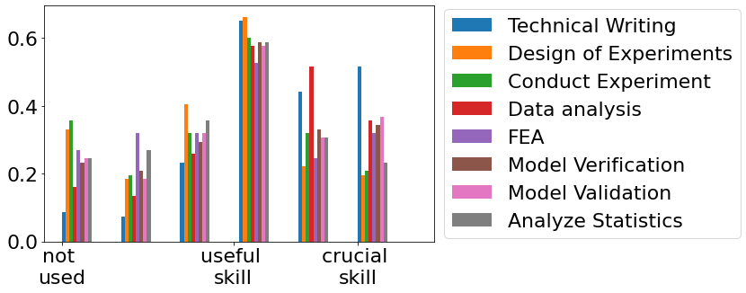

# Conclusions

[figure not shown]

- Students need opportunities for PBL and PjBL in every class
  - it improves tech writing
  - it connects empirical and analytical methods
- Jupyter is an *awesome* way to build open educational resources
  - connects empirical to analytical methods
  - interactive materials encourage experimentation and exploration
  - free and **open**: you can download/modify/redistribute *great for building student portfolios*
- Critera-based grading is first step to *my ungrading journey*
  - >80% of students liked the system
  - the failing cases were a mix of apathetic and enraged

# Lessons learned

- Community is crucial:
  - Establish safe and respectful communication
  - Encourage collaboration
- Students thrive with goals
- Test-taking students scared of open-ended assignments
  - Rubrics help (detailed, but not prescriptive)
  - Grace in deadlines and revisions helps

# Future work

[figure not shown]

- Criteria-based grading is my first step towards *ungrading*
- My classes *based upon this work* have moved to unlimited revisions *no tokens or P/F*
- Ideally, students create portfolio of engineering work
- My role would be:
  - identify resources
  - troubleshoot modeling/testing
  - teaching and learning

# Question + Discussions?

[figure not shown]